# Vaccines: Many Beliefs Pilot 5

Derek Powell

July 14, 2017

```r
filename <- "vb_pilot5.csv"
headers <- as.matrix(read.csv(filename, skip = 0, header = F, nrows = 1, as.is = T ))
df <- read.csv(filename, skip = 3, header = F)
colnames(df) <- headers
df <- df[which(df$Status==0),] # remove survey previews
# remove unused qualtrics variables
remove_cols <- c("RecipientLastName",
                 "RecipientFirstName",
                 "RecipientEmail",
                 "Finished",
                 "ResponseId",
                 "ExternalReference",
                 "DistributionChannel",
                 "UserLanguage",
                 "Status")
df <- df[ , -which(names(df) %in% remove_cols)]
df <- df[which(df$vaccDanger_check_3==3 & df$hb_check_5==5),]
```

```r
all_items <- c("hb_1",
"hb_2",
"hb_3",
"hb_4",
"nat_1",
"nat_2r",
"nat_3",
"nat_4",
"nat_5",
"nat_6r",
"medSkept_1",
"medSkept_2r",
"medSkept_3",
"medSkept_4",
"medSkept_5r",
"medSkept_6r",
"diseaseRare_1",
"diseaseRare_2",
"diseaseRare_3r",
"diseaseRare_4",
"diseaseRare_5r",
"diseaseSevere_1",
"diseaseSevere_2",
"diseaseSevere_3r",
"diseaseSevere_4",
"diseaseSevere_5r",
"diseaseSevere_6",
"vaccEff_1",
"vaccEff_2r",
"vaccEff_3r",
"vaccEff_4",
"vaccDanger_1",
"vaccDanger_2r",
"vaccDanger_3",
"vaccDanger_4r",
"vaccTox_1r",
"vaccTox_2",
"vaccTox_3",
"vaccTox_4r",
"vaccStrain_1",
"vaccStrain_2r",
"vaccStrain_3",
"vaccStrain_4r",
"vaccStrain_5",
"vaccIntent_1r",
"vaccIntent_2",
"vaccIntent_3r",
"vaccIntent_4",
"vaccIntent_5r",
"parentExpert_1",
"parentExpert_2",
"parentExpert_3",
"parentExpert_4r",
"parentExpert_5r",
"infantImmLimCap_1",
"infantImmLimCap_2r",
"infantImmLimCap_3",
"infantImmLimCap_4",
"infantImmLimCap_5r",
"infantImmWeak_1",
"infantImmWeak_2",
"infantImmWeak_3",
"infantImmWeak_4r",
"infantImmWeak_5r",
"overpar_1",
"overpar_2",
"overpar_3",
"overpar_4r",
"overpar_5r")
```

```r
library(ggplot2)
# df <- read.csv("vb_pilot2.csv")
reverse_items <- all_items[!sapply(
  lapply(all_items, function (x) {
  if (substr(x,nchar(x),nchar(x))=="r") {
    return(x)
  }
}), is.null)]

df[,reverse_items] <- lapply(df[,reverse_items], function(x) {
  8-x
})
df_main <- df[,all_items]
```

# Introduction

This is a notebook for the fifth pilot experiment of our (Kara, Ellen, and Derek) first pilot experiment examining vaccine theories using multiple attitude measures. We recruited 100 participants and lost 4 to comprehension checks, leaving 96.

# Item Correlations

Here’s a correlation matrix for all individual items. It appears items of some scales are intercorrelating well, though others are weaker. There is also considerable correlation among items across scales–as we might expect.

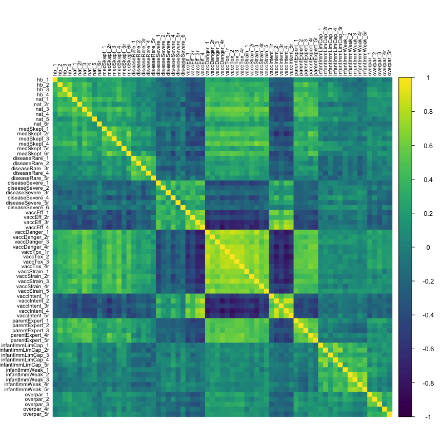

```r
library(corrplot)
library(viridis)
corrplot(cor(df_main),
         tl.cex=.65,
         tl.col="black",
         method="color",
         col=viridis(128))
```

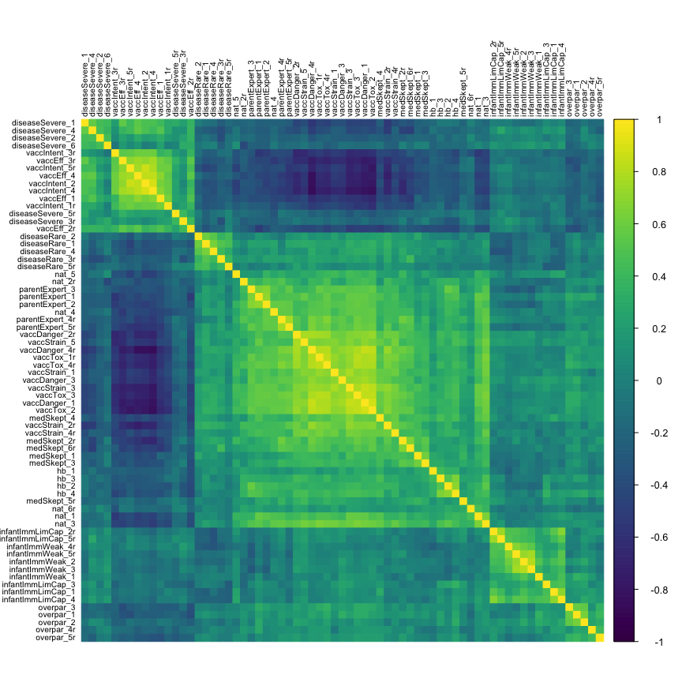

```r
corrplot(cor(df_main[,all_items]),
         order="hclust",
         # addrect=3,
         tl.cex=.65,
         tl.col="black",
         method="color",
         col=viridis(128))
```

# Scale Internal Consistency Reliability

# Problem scales

Below are computed chronbach’s alpha for all scales along with more detailed analyses of scales that are problematic.

## Disease Severity

Our changes to disease severity did not help at all and in fact hurt the reliability of the scale even with an additional item. I think we really need to iron out the issues in this scale, whether that means returning to the original or making new changes.

```r
diseaseSevere <- all_items[22:27]
diseaseSevere <- c("diseaseSevere_1",
"diseaseSevere_2",
"diseaseSevere_3r",
"diseaseSevere_4",
"diseaseSevere_5r",
"diseaseSevere_6")
diseaseSevere.alpha <- psych::alpha(df[,diseaseSevere])
diseaseSevere.alpha$total$raw_alpha
```

```
[1] 0.7115164
```

```r
diseaseSevere.alpha
```

```
Reliability analysis
Call: psych::alpha(x = df[, diseaseSevere])

  raw_alpha std.alpha G6(smc) average_r S/N   ase mean   sd
      0.71      0.73    0.74      0.31 2.7 0.047  5.5 0.88

 lower alpha upper     95% confidence boundaries
0.62 0.71 0.8

 Reliability if an item is dropped:
                 raw_alpha std.alpha G6(smc) average_r S/N alpha se
diseaseSevere_1       0.63      0.65    0.64      0.27 1.8    0.060
diseaseSevere_2       0.65      0.67    0.68      0.29 2.1    0.057
diseaseSevere_3r      0.69      0.72    0.70      0.33 2.5    0.052
diseaseSevere_4       0.66      0.68    0.67      0.30 2.1    0.055
diseaseSevere_5r      0.73      0.74    0.71      0.36 2.8    0.045
diseaseSevere_6       0.67      0.69    0.68      0.31 2.2    0.054

 Item statistics
                  n raw.r std.r r.cor r.drop mean  sd
diseaseSevere_1  96  0.73  0.76  0.72   0.59  5.8 1.2
diseaseSevere_2  96  0.68  0.70  0.61   0.51  5.3 1.3
diseaseSevere_3r 96  0.63  0.59  0.46   0.40  5.4 1.5
diseaseSevere_4  96  0.64  0.69  0.62   0.49  5.9 1.1
diseaseSevere_5r 96  0.56  0.52  0.38   0.30  5.9 1.6
diseaseSevere_6  96  0.66  0.66  0.57   0.45  4.9 1.5

Non missing response frequency for each item
                    1    2    3    4    5    6    7 miss
diseaseSevere_1  0.01 0.01 0.02 0.08 0.22 0.36 0.29    0
diseaseSevere_2  0.01 0.01 0.02 0.27 0.22 0.27 0.20    0
diseaseSevere_3r 0.00 0.04 0.09 0.16 0.14 0.27 0.30    0
diseaseSevere_4  0.01 0.01 0.01 0.06 0.20 0.38 0.33    0
diseaseSevere_5r 0.03 0.03 0.05 0.05 0.10 0.23 0.50    0
diseaseSevere_6  0.03 0.03 0.09 0.23 0.27 0.20 0.15    0
```

### Diagnosing

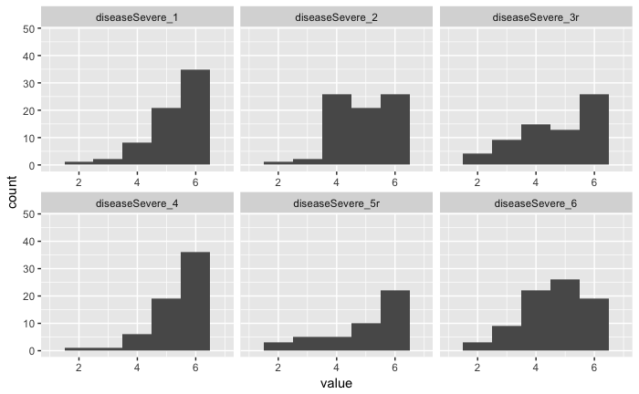

```r
library(ggplot2)
library(reshape2)
ggplot(data = melt(df[,diseaseSevere]), mapping = aes(x = value)) +
    geom_histogram(bins = 7) + facet_wrap(~variable, scales = 'free_x') + xlim(1,7)
```

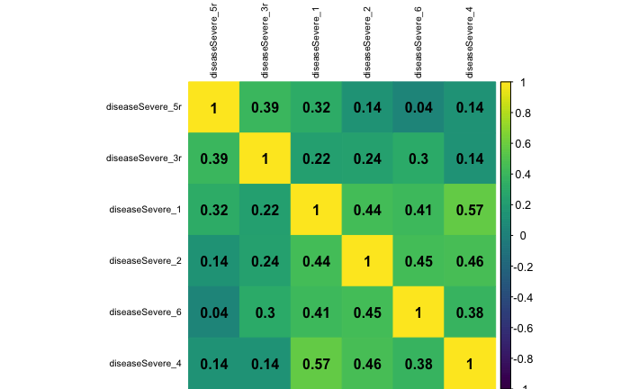

```r
corrplot(cor(df[,diseaseSevere]),
         order="AOE",
         tl.cex=.65,
         tl.col="black",
         method="color",
         addCoef.col="black",
         col=viridis(128))
```

## Naturalism

This scale improved very slightly, looks like we can remove either 5 or 6r and retain an alpha of .78. Since removing 6r makes this basically the original scale I think we can say that the difference between that score (.78) and the .825 it scored earlier is essentially just noise. As a spoiler, I looked at the consistency in the alpha scores for the unchanged scales (n=10) across pilot 4 and 5. The average absolute difference was .021 and the SD of the differences was .025. So I guess that makes me less interested in reading into changes or differences smaller than those values, and we should only really be struck by changes greater than .049 or so.

```r
nat <- all_items[5:10]
naturalism.alpha <- psych::alpha(df[,nat])
naturalism.alpha$total$raw_alpha
```

```
[1] 0.7775232
```

```r
naturalism.alpha
```

```
Reliability analysis
Call: psych::alpha(x = df[, nat])

  raw_alpha std.alpha G6(smc) average_r S/N   ase mean  sd
      0.78      0.77    0.77      0.36 3.4 0.034  3.6 1.2

 lower alpha upper     95% confidence boundaries
0.71 0.78 0.84

 Reliability if an item is dropped:
       raw_alpha std.alpha G6(smc) average_r S/N alpha se
nat_1       0.69      0.69    0.67      0.31 2.3    0.049
nat_2r      0.76      0.75    0.75      0.38 3.1    0.038
nat_3       0.70      0.70    0.68      0.32 2.3    0.047
nat_4       0.74      0.73    0.71      0.35 2.7    0.040
nat_5       0.78      0.78    0.77      0.42 3.6    0.035
nat_6r      0.78      0.77    0.75      0.40 3.4    0.034

 Item statistics
        n raw.r std.r r.cor r.drop mean  sd
nat_1  96  0.83  0.81  0.80   0.71  4.5 2.0
nat_2r 96  0.62  0.64  0.53   0.47  2.9 1.5
nat_3  96  0.81  0.80  0.78   0.69  4.1 1.9
nat_4  96  0.71  0.71  0.64   0.55  3.3 1.9
nat_5  96  0.53  0.56  0.40   0.36  2.6 1.5
nat_6r 96  0.61  0.59  0.46   0.40  4.3 2.0

Non missing response frequency for each item
          1    2    3    4    5    6    7 miss
nat_1  0.10 0.11 0.07 0.12 0.23 0.15 0.21    0
nat_2r 0.12 0.41 0.19 0.15 0.06 0.02 0.05    0
nat_3  0.10 0.14 0.14 0.16 0.21 0.12 0.14    0
nat_4  0.20 0.26 0.11 0.17 0.09 0.10 0.06    0
nat_5  0.30 0.29 0.10 0.22 0.02 0.04 0.02    0
nat_6r 0.08 0.20 0.10 0.10 0.15 0.23 0.14    0
```

## Overparenting with babies (new scale)

This improved considerably, though it’s still a tad low. Looks like item 4r is weak.

```r
overPar <- all_items[65:69]
overPar.alpha <- psych::alpha(df[,overPar])
overPar.alpha
```

```
Reliability analysis
Call: psych::alpha(x = df[, overPar])

  raw_alpha std.alpha G6(smc) average_r S/N   ase mean  sd
      0.77      0.76    0.76      0.39 3.2 0.037    4 1.2

 lower alpha upper     95% confidence boundaries
0.69 0.77 0.84

 Reliability if an item is dropped:
           raw_alpha std.alpha G6(smc) average_r S/N alpha se
overpar_1       0.67      0.67    0.65      0.34 2.1    0.054
overpar_2       0.69      0.69    0.67      0.36 2.2    0.050
overpar_3       0.72      0.72    0.69      0.39 2.5    0.046
overpar_4r      0.78      0.78    0.75      0.47 3.6    0.036
overpar_5r      0.74      0.73    0.71      0.41 2.7    0.041

 Item statistics
            n raw.r std.r r.cor r.drop mean  sd
overpar_1  96  0.82  0.81  0.77   0.68  4.6 1.7
overpar_2  96  0.78  0.78  0.72   0.64  5.0 1.6
overpar_3  96  0.77  0.73  0.65   0.56  4.0 2.0
overpar_4r 96  0.53  0.58  0.42   0.34  3.3 1.3
overpar_5r 96  0.68  0.69  0.57   0.49  3.1 1.6

Non missing response frequency for each item
              1    2    3    4    5    6    7 miss
overpar_1  0.05 0.07 0.16 0.09 0.28 0.23 0.11    0
overpar_2  0.03 0.05 0.06 0.24 0.23 0.17 0.22    0
overpar_3  0.09 0.19 0.20 0.06 0.16 0.18 0.12    0
overpar_4r 0.06 0.20 0.36 0.18 0.14 0.05 0.01    0
overpar_5r 0.18 0.22 0.29 0.12 0.10 0.04 0.04    0
```

### Diagnosing

Items 3 and 4r really don’t correlate.

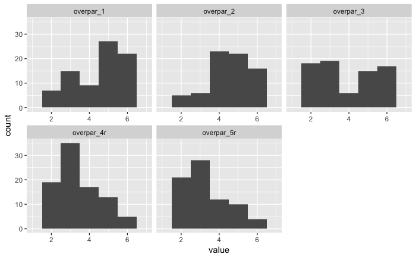

```r
ggplot(data = melt(df[,overPar]), mapping = aes(x = value)) +
    geom_histogram(bins = 7) + facet_wrap(~variable, scales = 'free_x') + xlim(1,7)
```

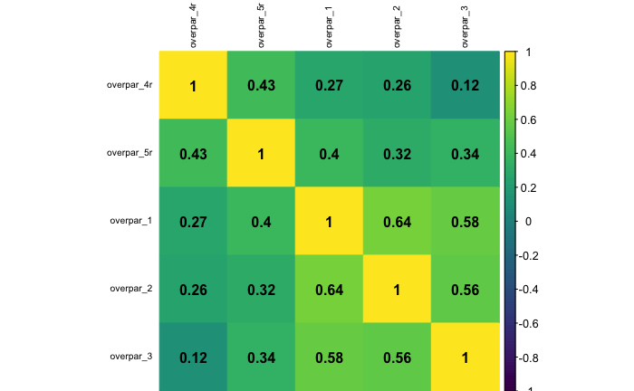

```r
corrplot(cor(df[,overPar]),
         order="AOE",
         tl.cex=.65,
         tl.col="black",
         method="color",
         addCoef.col="black",
         col=viridis(128))
```

# Acceptable scales

The remaining scales are (within rounding) in the acceptable reliabiltiy range.

## Holistic Balance

In pilot 4 the reliability of this was just below threshold, here it’s just above.

```r
hb <- all_items[1:4]
hb.alpha <- psych::alpha(df[,hb])
hb.alpha$total$raw_alpha
```

```
[1] 0.8017356
```

## Disease Rarity

```r
diseaseRare <- all_items[17:21]
diseaseRare.alpha <- psych::alpha(df[,diseaseRare])
diseaseRare.alpha$total$raw_alpha
```

```
[1] 0.8134867
```

## Vaccine Effectiveness

```r
vaccEff <- all_items[28:31]
vaccEff.alpha <- psych::alpha(df[,vaccEff])
vaccEff.alpha$total$raw_alpha
```

```
[1] 0.851011
```

## Vaccine Danger

```r
vaccDanger <- all_items[32:35]
vaccDanger.alpha <- psych::alpha(df[,vaccDanger])
vaccDanger.alpha$total$raw_alpha
```

```
[1] 0.9142527
```

## Vaccines are toxic

```r
vaccTox <- all_items[36:39]
vaccTox.alpha <- psych::alpha(df[,vaccTox])
vaccTox.alpha$total$raw
```

```
[1] 0.9476674
```

## Medical Skepticism

This is just making the grade now and looks like we are safe to remove 5r without harming reliability, though I think it’s kind of an important part of the idea. So maybe we are left to choose between a 5 item scale and a scale with that item included.

```r
medSkept <- all_items[11:16]
medSkept.alpha <- psych::alpha(df[,medSkept])
medSkept.alpha$total$raw_alpha
```

```
[1] 0.8172651
```

```r
medSkept.alpha
```

```
Reliability analysis
Call: psych::alpha(x = df[, medSkept])

  raw_alpha std.alpha G6(smc) average_r S/N   ase mean  sd
      0.82      0.82    0.81      0.43 4.5 0.029    4 1.1

 lower alpha upper     95% confidence boundaries
0.76 0.82 0.87

 Reliability if an item is dropped:
            raw_alpha std.alpha G6(smc) average_r S/N alpha se
medSkept_1       0.77      0.78    0.76      0.41 3.5    0.037
medSkept_2r      0.78      0.78    0.75      0.41 3.5    0.036
medSkept_3       0.77      0.77    0.75      0.40 3.4    0.038
medSkept_4       0.80      0.80    0.79      0.45 4.1    0.032
medSkept_5r      0.83      0.83    0.81      0.49 4.8    0.028
medSkept_6r      0.78      0.78    0.75      0.41 3.5    0.036

 Item statistics
             n raw.r std.r r.cor r.drop mean  sd
medSkept_1  96  0.77  0.77  0.72   0.65  5.1 1.6
medSkept_2r 96  0.75  0.76  0.72   0.63  2.9 1.5
medSkept_3  96  0.79  0.78  0.74   0.66  4.1 1.7
medSkept_4  96  0.68  0.67  0.56   0.51  3.6 1.6
medSkept_5r 96  0.59  0.59  0.45   0.41  5.3 1.6
medSkept_6r 96  0.76  0.77  0.72   0.64  2.8 1.5

Non missing response frequency for each item
               1    2    3    4    5    6    7 miss
medSkept_1  0.02 0.05 0.10 0.14 0.25 0.23 0.21    0
medSkept_2r 0.11 0.30 0.38 0.06 0.07 0.02 0.05    0
medSkept_3  0.09 0.09 0.15 0.23 0.22 0.14 0.08    0
medSkept_4  0.09 0.23 0.12 0.25 0.16 0.11 0.03    0
medSkept_5r 0.03 0.04 0.06 0.18 0.12 0.28 0.28    0
medSkept_6r 0.23 0.27 0.23 0.16 0.03 0.06 0.02    0
```

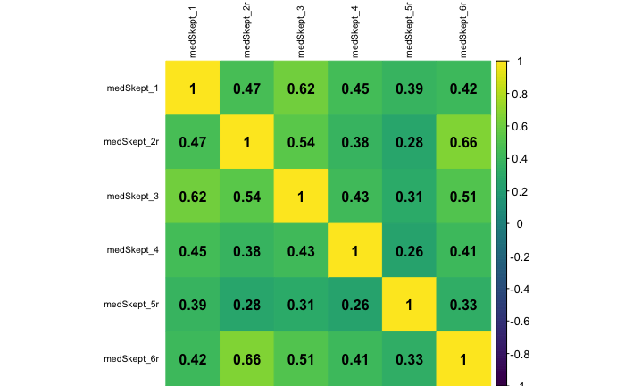

```r
corrplot(cor(df[,medSkept]),
         order="alpha",
         tl.cex=.65,
         tl.col="black",
         method="color",
         addCoef.col="black",
         col=viridis(128))
```

## Vaccination Intentions

```r
vaccIntent <- all_items[45:49]
vaccIntent.alpha <- psych::alpha(df[,vaccIntent])
vaccIntent.alpha$total$raw_alpha
```

```
[1] 0.8921135
```

## Parental Expertise

Success! Reliability is very solid.

```r
parExpert <- all_items[50:54]
parExpert.alpha <- psych::alpha(df[,parExpert])
parExpert.alpha$total$raw_alpha
```

```
[1] 0.8740609
```

```r
parExpert.alpha
```

```
Reliability analysis
Call: psych::alpha(x = df[, parExpert])

  raw_alpha std.alpha G6(smc) average_r S/N  ase mean  sd
      0.87      0.88    0.88      0.59 7.1 0.02  3.4 1.4

 lower alpha upper     95% confidence boundaries
0.83 0.87 0.91

 Reliability if an item is dropped:
                raw_alpha std.alpha G6(smc) average_r S/N alpha se
parentExpert_1       0.85      0.85    0.85      0.59 5.8    0.025
parentExpert_2       0.83      0.84    0.83      0.56 5.1    0.029
parentExpert_3       0.85      0.85    0.85      0.59 5.8    0.026
parentExpert_4r      0.86      0.86    0.83      0.60 6.1    0.023
parentExpert_5r      0.85      0.85    0.82      0.59 5.7    0.025

 Item statistics
                 n raw.r std.r r.cor r.drop mean  sd
parentExpert_1  96  0.82  0.81  0.75   0.70  4.3 1.9
parentExpert_2  96  0.87  0.86  0.82   0.77  3.7 1.8
parentExpert_3  96  0.81  0.81  0.75   0.70  3.1 1.6
parentExpert_4r 96  0.79  0.79  0.75   0.66  3.4 1.7
parentExpert_5r 96  0.80  0.82  0.78   0.71  2.6 1.4

Non missing response frequency for each item
                   1    2    3    4    5    6    7 miss
parentExpert_1  0.10 0.11 0.12 0.08 0.28 0.18 0.11    0
parentExpert_2  0.18 0.11 0.15 0.15 0.27 0.09 0.05    0
parentExpert_3  0.20 0.21 0.25 0.12 0.15 0.03 0.04    0
parentExpert_4r 0.10 0.28 0.22 0.10 0.16 0.06 0.07    0
parentExpert_5r 0.20 0.41 0.24 0.04 0.05 0.04 0.02    0
```

Looks a little two-dimensional though. Items 4 and 5 are both about trusing doctors’ advice, so I suppose it’s not surprising they hang together even more strongly.

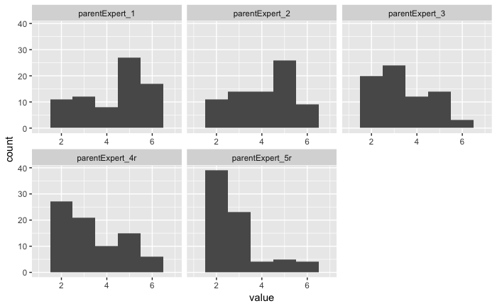

```r
library(ggplot2)
library(reshape2)
ggplot(data = melt(df[,parExpert]), mapping = aes(x = value)) +
    geom_histogram(bins = 7) + facet_wrap(~variable, scales = 'free_x') + xlim(1,7)
```

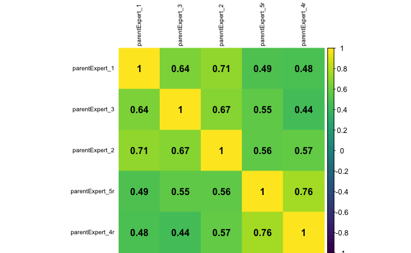

```r
corrplot(cor(df[,parExpert]),
         order="AOE",
         tl.cex=.65,
         tl.col="black",
         method="color",
         addCoef.col="black",
         col=viridis(128))
```

## Infant immune system has limited capacity

Reliability is now very good.

```r
immCap <- all_items[55:59]
immCap.alpha <- psych::alpha(df[,immCap])
immCap.alpha$total$raw_alpha
```

```
[1] 0.8398381
```

```r
immCap.alpha
```

```
Reliability analysis
Call: psych::alpha(x = df[, immCap])

  raw_alpha std.alpha G6(smc) average_r S/N   ase mean  sd
      0.84      0.84    0.85      0.51 5.3 0.026  4.5 1.1

 lower alpha upper     95% confidence boundaries
0.79 0.84 0.89

 Reliability if an item is dropped:
                   raw_alpha std.alpha G6(smc) average_r S/N alpha se
infantImmLimCap_1       0.80      0.80    0.80      0.51 4.1    0.034
infantImmLimCap_2r      0.78      0.78    0.76      0.48 3.6    0.037
infantImmLimCap_3       0.85      0.86    0.85      0.60 6.0    0.025
infantImmLimCap_4       0.77      0.77    0.76      0.46 3.3    0.039
infantImmLimCap_5r      0.82      0.82    0.80      0.53 4.6    0.030

 Item statistics
                    n raw.r std.r r.cor r.drop mean  sd
infantImmLimCap_1  96  0.79  0.79  0.73   0.66  4.6 1.5
infantImmLimCap_2r 96  0.84  0.84  0.82   0.74  4.5 1.4
infantImmLimCap_3  96  0.65  0.65  0.51   0.46  4.1 1.4
infantImmLimCap_4  96  0.87  0.87  0.85   0.78  4.8 1.4
infantImmLimCap_5r 96  0.76  0.75  0.69   0.60  4.4 1.5

Non missing response frequency for each item
                      1    2    3    4    5    6    7 miss
infantImmLimCap_1  0.04 0.01 0.15 0.26 0.26 0.17 0.11    0
infantImmLimCap_2r 0.01 0.04 0.18 0.32 0.18 0.17 0.10    0
infantImmLimCap_3  0.04 0.12 0.09 0.35 0.21 0.15 0.03    0
infantImmLimCap_4  0.02 0.03 0.09 0.29 0.24 0.20 0.12    0
infantImmLimCap_5r 0.02 0.09 0.17 0.27 0.21 0.12 0.11    0
```

## Infants’ immune systems are weak

Looks good!

```r
immWeak <- all_items[60:64]
immWeak.alpha <- psych::alpha(df[,immWeak])
immWeak.alpha$total$raw_alpha
```

```
[1] 0.8655586
```

```r
immWeak.alpha
```

```
Reliability analysis
Call: psych::alpha(x = df[, immWeak])

  raw_alpha std.alpha G6(smc) average_r S/N   ase mean  sd
      0.87      0.87    0.87      0.57 6.6 0.022  4.5 1.2

 lower alpha upper     95% confidence boundaries
0.82 0.87 0.91

 Reliability if an item is dropped:
                 raw_alpha std.alpha G6(smc) average_r S/N alpha se
infantImmWeak_1       0.90      0.90    0.88      0.68 8.6    0.018
infantImmWeak_2       0.80      0.80    0.79      0.51 4.1    0.034
infantImmWeak_3       0.82      0.82    0.80      0.53 4.6    0.031
infantImmWeak_4r      0.85      0.85    0.85      0.59 5.9    0.026
infantImmWeak_5r      0.81      0.81    0.80      0.52 4.3    0.033

 Item statistics
                  n raw.r std.r r.cor r.drop mean  sd
infantImmWeak_1  96  0.65  0.64  0.49   0.45  4.6 1.6
infantImmWeak_2  96  0.90  0.90  0.89   0.83  4.7 1.5
infantImmWeak_3  96  0.85  0.86  0.84   0.77  4.8 1.4
infantImmWeak_4r 96  0.77  0.77  0.69   0.63  4.1 1.5
infantImmWeak_5r 96  0.88  0.88  0.86   0.79  4.1 1.6

Non missing response frequency for each item
                    1    2    3    4    5    6    7 miss
infantImmWeak_1  0.03 0.09 0.14 0.14 0.30 0.18 0.12    0
infantImmWeak_2  0.02 0.08 0.11 0.21 0.24 0.24 0.09    0
infantImmWeak_3  0.02 0.04 0.16 0.15 0.30 0.23 0.10    0
infantImmWeak_4r 0.03 0.11 0.22 0.28 0.17 0.10 0.08    0
infantImmWeak_5r 0.04 0.10 0.23 0.23 0.20 0.10 0.09    0
```

## Vaccines strain the immune system

Now with five items this makes for a very reliable scale.

```r
vaccStrain <- all_items[40:44]
# cor(df$immStrain_1,df$immStrain_2r)
vaccStrain.alpha <- psych::alpha(df[,vaccStrain])
vaccStrain.alpha
```

```
Reliability analysis
Call: psych::alpha(x = df[, vaccStrain])

  raw_alpha std.alpha G6(smc) average_r S/N   ase mean  sd
       0.9       0.9    0.89      0.64 8.9 0.016  3.4 1.5

 lower alpha upper     95% confidence boundaries
0.87 0.9 0.93

 Reliability if an item is dropped:
              raw_alpha std.alpha G6(smc) average_r S/N alpha se
vaccStrain_1       0.87      0.87    0.85      0.63 6.8    0.021
vaccStrain_2r      0.89      0.89    0.87      0.67 8.1    0.018
vaccStrain_3       0.86      0.86    0.82      0.60 6.0    0.024
vaccStrain_4r      0.88      0.88    0.87      0.66 7.6    0.019
vaccStrain_5       0.88      0.88    0.86      0.65 7.4    0.019

 Item statistics
               n raw.r std.r r.cor r.drop mean  sd
vaccStrain_1  96  0.87  0.86  0.83   0.78  3.3 1.8
vaccStrain_2r 96  0.79  0.80  0.74   0.69  2.9 1.5
vaccStrain_3  96  0.91  0.90  0.89   0.84  3.3 1.9
vaccStrain_4r 96  0.82  0.82  0.75   0.72  3.6 1.7
vaccStrain_5  96  0.84  0.83  0.77   0.73  3.9 1.8

Non missing response frequency for each item
                 1    2    3    4    5    6    7 miss
vaccStrain_1  0.17 0.22 0.20 0.16 0.14 0.06 0.06    0
vaccStrain_2r 0.16 0.32 0.26 0.11 0.07 0.04 0.03    0
vaccStrain_3  0.22 0.21 0.12 0.19 0.07 0.10 0.08    0
vaccStrain_4r 0.10 0.22 0.14 0.25 0.18 0.05 0.06    0
vaccStrain_5  0.10 0.19 0.12 0.23 0.12 0.12 0.10    0
```

# Scale Distributions

```r
df_scales<-df_main
df_scales$holBalance <- rowMeans(df[,hb])
df_scales$naturalism <- rowMeans(df[,nat])
df_scales$diseaseRare <- rowMeans(df[,diseaseRare])
df_scales$diseaseSevere <- rowMeans(df[,diseaseSevere])
df_scales$vaccEff <- rowMeans(df[,vaccEff])
df_scales$vaccDanger <- rowMeans(df[,vaccDanger])
df_scales$medSkept <- rowMeans(df[,medSkept])
df_scales$vaccIntent <- rowMeans(df[,vaccIntent])
# df_scales$parDuty <- rowMeans(df[,parDuty])
df_scales$parExpert <- rowMeans(df[,parExpert])
df_scales$immCap <- rowMeans(df[,immCap])
# df_scales$immSympt <- rowMeans(df[,immSympt])
df_scales$immWeak <- rowMeans(df[,immWeak])
df_scales$vaccStrain <- rowMeans(df[,vaccStrain])
df_scales$vaccTox <- rowMeans(df[,vaccTox])
df_scales$overParenting <- rowMeans(df[,overPar])
```

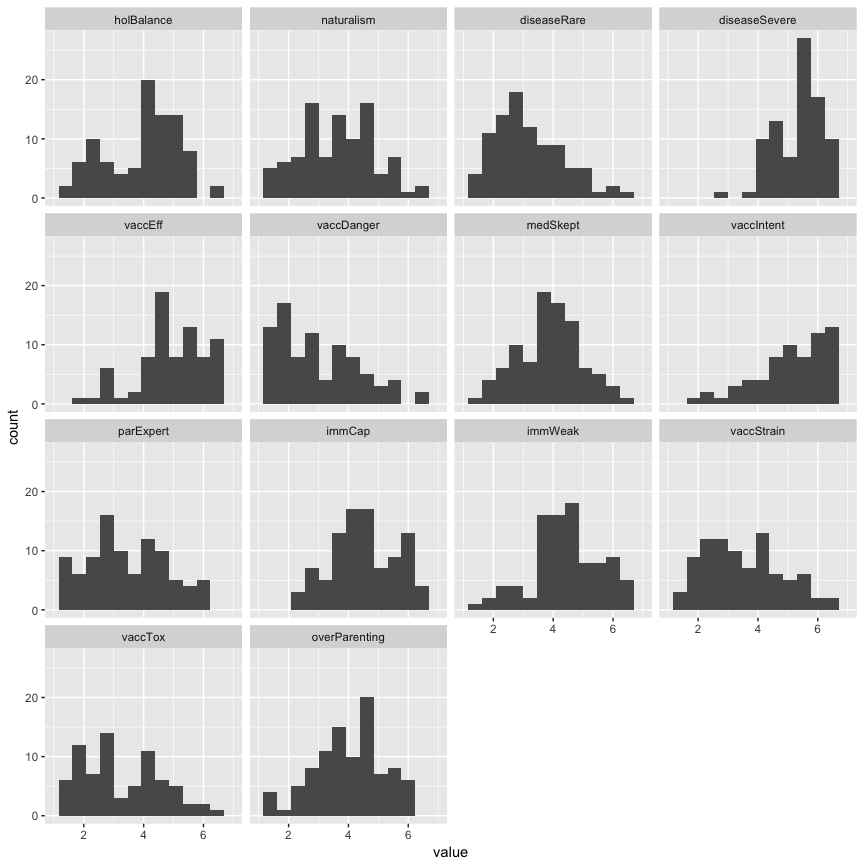

```r
library(ggplot2)
library(reshape2)
scale_vars <- c("holBalance",
                "naturalism",
                "diseaseRare",
                "diseaseSevere",
                "vaccEff",
                "vaccDanger",
                "medSkept",
                "vaccIntent",
                "parExpert",
                "immCap",
                "immWeak",
                "vaccStrain",
                "vaccTox",
                "overParenting")
# df_hist <- df_scales[,scale_vars]
plt.hist <- ggplot(data = melt(df_scales[,scale_vars]), mapping = aes(x = value)) +
    geom_histogram(bins = 14) + facet_wrap(~variable) + xlim(1,7)
# ggsave("scale_hists.png",plt.hist)
plt.hist
```

# Scale correlations

Some of this is expected and some is a bit surprising. Of course once we start taking into account other conditional dependencies, some of these correlations could change, or even reverse sign.

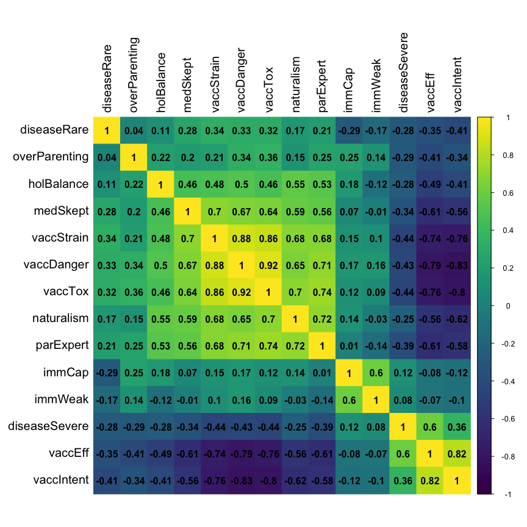

```r
corrplot(cor(df_scales[,scale_vars]),
         order="hclust",
         tl.cex=1.25,
         tl.col="black",
         method="color",
         addCoef.col="black",
         col=viridis(128))
```

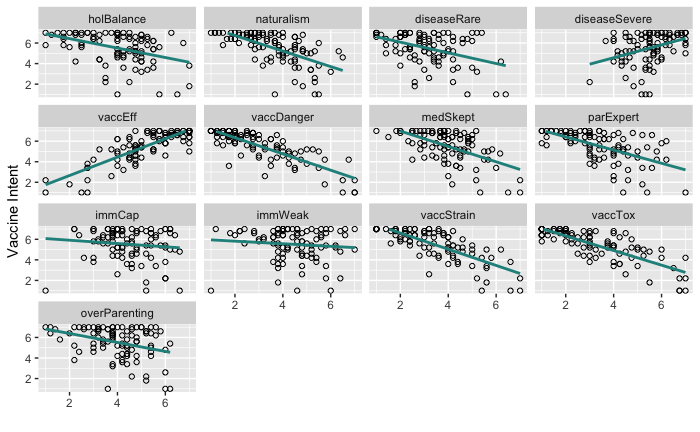

```r
df_long <- df_scales
df_long$y_val <- df_long$vaccIntent
df_long <- reshape(df_long, idvar="workerId", timevar = "item", direction="long",
             varying=list(x_val = scale_vars[-8]),
             v.names = c("x_val"))
df_long$item <- factor(df_long$item,
                       levels = seq(1,13,1),
                       labels=scale_vars[-8])
plt.scatter <- ggplot(data = df_long, mapping = aes(x = x_val, y=y_val)) +
    geom_point(shape=1) +
  geom_smooth(method="lm", se=FALSE, col=viridis_pal()(5)[3]) +
  facet_wrap(~item) +
  xlim(1,7) + ylim(1,7) + labs(y="Vaccine Intent", x="")
# ggsave("scale_scatter.png",plt.scatter)
plt.scatter
```

# Coefficient $\omega$ reliability

Coefficient $\alpha$ has a number of well-known problems, not the least of which it is often biased (either under or over-estimating). Most people who know now recommend the use of coeffiicent $\omega$, because it is unbiased and also readily interpretable: $\omega$ represents the proportion of variance in scale scores accounted for by the latent factor.

Here I’m calculating robust $\omega$ using the coefficientalpha package. A (non-robust?) implementation is also available in the psych package that relies on an SEM package.

If $\omega$ is to be trusted it looks like the bias in $\alpha$ is leading to an underestimate of the reliability of most scales.

## Naturalism

```r
coefficientalpha::omega(df[,nat])
```

```
Test of homogeneity
The robust F statistic is  0.763
with a p-value  0.6507

The omega is 0.8193985.
About 16.67% of cases were downweighted.
```

## DiseaseSeverity

Still doesn’t make the grade according to omega

```r
coefficientalpha::omega(df[,diseaseSevere])
```

```
Test of homogeneity
The robust F statistic is  1.157
with a p-value  0.3329

The omega is 0.7527882.
About 17.71% of cases were downweighted.
```

## Over-parenting

Makes the grade according to omega

```r
coefficientalpha::omega(df[,overPar])
```

```
Test of homogeneity
The robust F statistic is  2.236
with a p-value  0.0573

The omega is 0.8022485.
About 12.5% of cases were downweighted.
```

## Medical skepticism

```r
coefficientalpha::omega(df[,medSkept])
```

```
Test of homogeneity
The robust F statistic is  1.726
with a p-value  0.095

The omega is 0.8325494.
About 15.62% of cases were downweighted.
```

## Disease Rarity

```r
coefficientalpha::omega(df[,diseaseRare])
```

[output not shown]

# Comparing studies

As mentioned in the naturalism scale section, I looked at the consistency in the alpha scores for the unchanged scales (n=10) across pilot 4 and 5. The average absolute difference was .021 and the SD of the differences was .025. So I guess that makes me less interested in reading into changes or differences smaller than those values, and we should only really be struck by changes greater than .049 or so. The alpha values correlate at *r* = .89 across studies.